Empresa: Celular Global HATCO

# Análise de dados para planejamento de Marketing 2018

#### Assistentes: Beatriz Silva Nascimento, Beatriz Valentim Mendes, Maria Luiza Silveira Birra

### 1– Introdução

Tendo em vista o propósito de construir estratégias de propaganda e marketing para o ano de 2018, está análise visa delimitar o perfil dos consumidores da empresa Celular Global HATCO. Buscando ter uma visão geral da vigente situação da instituição será observada a interação entre as variáveis que afetam diretamente nos resultados do exercício anual desta. Com o estudo e seus respectivos passos, ao fim, obteremos um norte para o ano vindouro através do usual comportamento dos nossos clientes, buscando a melhora no atendimento deles, e, consequentemente, um melhor futuro para nossa organização.

### 2 – Metodologia

Com o fim de encontrar créditos e pontos danosos à eficiência e eficácia da empresa e para uma melhor análise destes, as informações obtidas (“Lista 1” do apêndice) pelo banco de dados (HATCO.xlsx.) disponibilizado pelo setor de pesquisa aplicada foram distribuídos em grupos. Tais grupos foram designados com relação à natureza das variáveis – qualitativa nominal e ordinal e quantitativa contínua -, como consta na denominada “Lista 2” do apêndice. A partir disso, elas foram combinadas para uma melhor obtenção do resultado requerido. A amostragem, composta de 100 consumidores, teve suas variáveis renomeadas para haver um estudo mais garantido, devido a nomeação do banco ter se apresentado em uma espécie de código e respectivos detalhes, quanto a pontuação, por exemplo, foram corrigidos. Ela foi trabalhada com o apoio do Software R-project – por ser um material de alto nível, preferível para gerar estatísticas de alta qualidade, para uma melhor compreensão e avaliação segura – visando um produtivo estudo.

Para elaborar um panorama do perfil do consumidor da empresa foram fixadas alguns tópicos com hipóteses embutidas:

- Clientes por Localidade
- Velocidade de entrega nas regiões
- Condição financeira dos Consumidores
- Imagem do Fabricante e Imagem da Força de Vendas
- Embalagem (Avaliação)
- Relação entre Celulares comprados e o nível de Satisfação
- Qualidade do Produto
- Acesso à Internet por Localidade
- Relação:Idade e Sexo

### 3 – Resultados encontrados

#### Experiência “Clientes por Localidade”

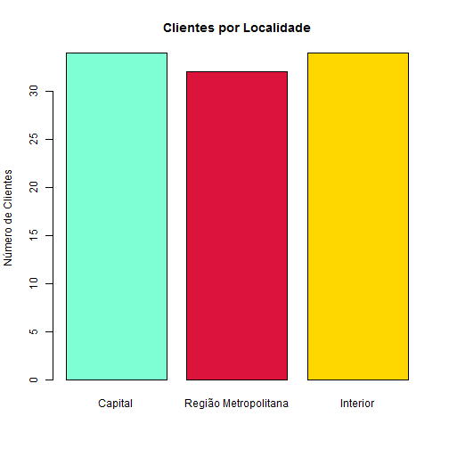

```r
barplot(table(cel$X14LocaldaCompra), xlab="", ylab="Número de Clientes",
  main="Clientes por Localidade",col=c("#7FFFD4","#DC143C","#FFD700"))
```

```r
X11()
```

#### Experiência “Velocidade de Entrega nas Regiões” 1

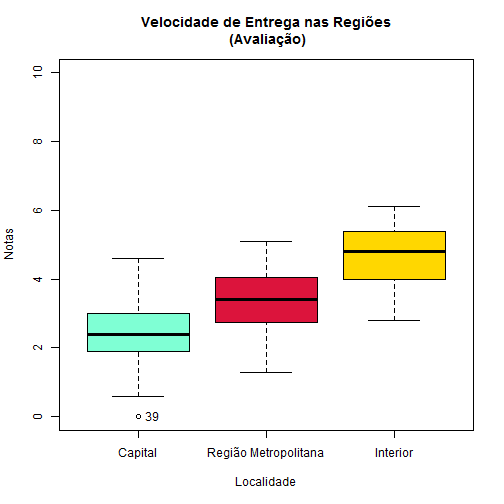

```
## [1] "39"
```

```r
Boxplot(X1VelocidadedeEntrega~X14LocaldaCompra, data=cel, id.method="y",
  xlab="Localidade",
  ylab="Notas",ylim=c(0,10),
  main="Velocidade de Entrega nas Regiões\n (Avaliação)",col=c("#7FFFD4",
  "#DC143C","#FFD700"))
```

```r
x11()
```

#### Experiência “Velocidade de Entrega nas Regiões” 2

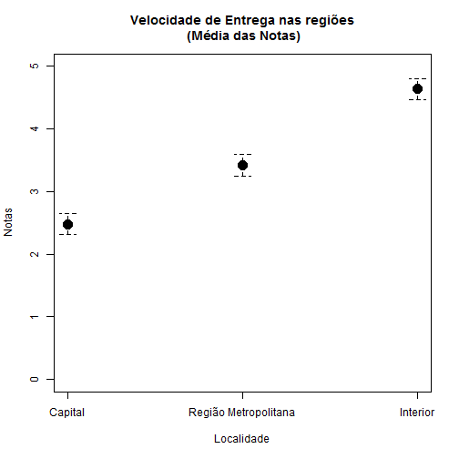

```r
with(cel, plotMeans(X1VelocidadedeEntrega, X14LocaldaCompra,
  error.bars="se", xlab="Localidade", ylab="Notas",ylim=c(0,5),
  main="Velocidade de Entrega nas regiões\n (Média das Notas)",
  connect=FALSE))
```

```r
x11()
```

#### Experiência “Condição Financeira dos Consumidores” 1

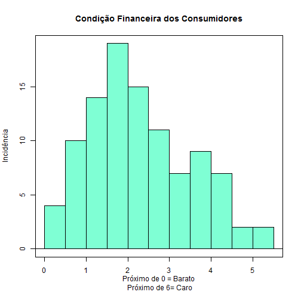

```r
with(cel, Hist(X2PreçodoProduto, scale="frequency", breaks="Sturges",
  col="#7FFFD4", xlab="Próximo de 0 = Barato\n Próximo de 6= Caro",
  ylab="Incidência", main="Condição Financeira dos Consumidores"))
```

```r
x11()
```

#### Experiência “Condição Financeira dos Consumidores” 2

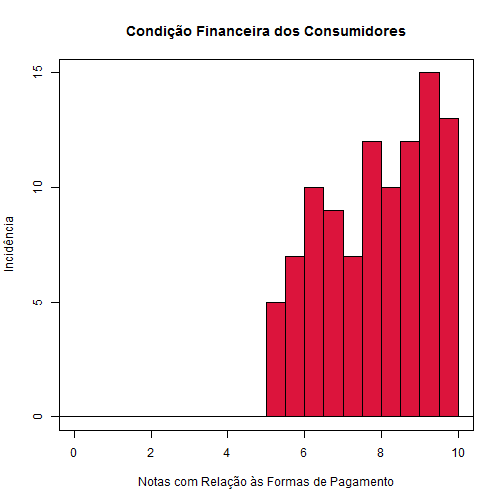

```r
with(cel, Hist(X3FlexibilidadedePreços, scale="frequency", breaks="Sturges",
   col="#DC143C", xlab="Notas com Relação às Formas de Pagamento",xlim=c(0,
  10),
  ylab="Incidência", main="Condição Financeira dos Consumidores"))
```

```r
x11()
```

#### Experiência “Imagem do Fabricante”

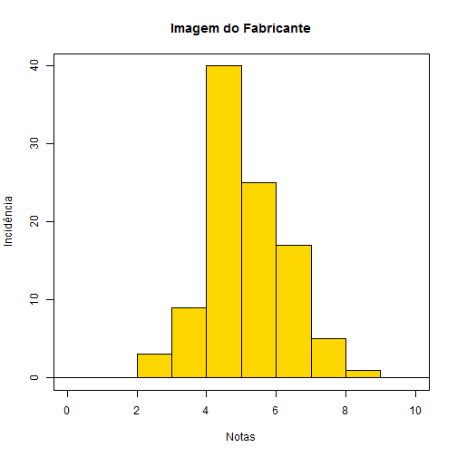

```r
with(cel, Hist(X4ImagemdoFabricante, scale="frequency", breaks="Sturges",
  col="#FFD700", xlab="Notas", ylab="Incidência",xlim=c(0,10),
  main="Imagem do Fabricante"))
```

```r
x11()
```

#### Experiência “Imagem da Força de Vendas”

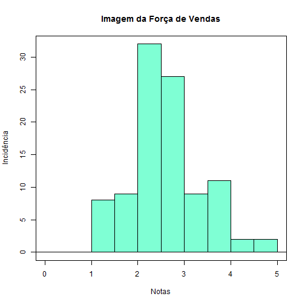

```r
with(cel, Hist(X6ImagemdaForçadeVendas, scale="frequency", breaks="Sturges",
   col="#7FFFD4", xlab="Notas", ylab="Incidência", xlim=c(0,5),
  main="Imagem da Força de Vendas"))
```

#### Experiência “Embalagem”

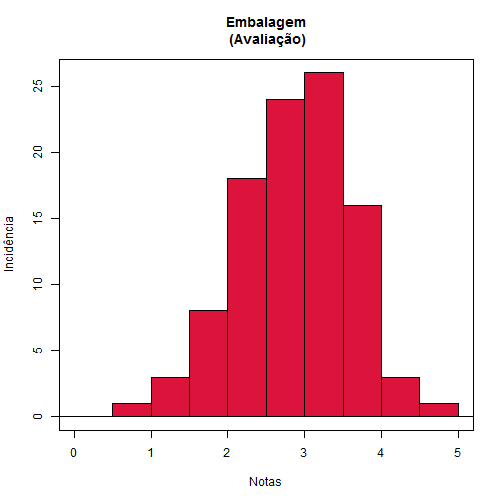

```r
with(cel, Hist(X5AvaliaçãodaEmbalagem, scale="frequency", breaks="Sturges",
  col="#DC143C", xlab="Notas", ylab="Incidência", xlim=c(0,5),
  main="Embalagem\n (Avaliação)"))
```

```r
x11()
```

#### Experiência “Relação”

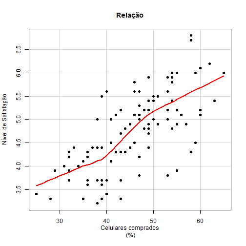

```r
scatterplot(X10NíveldeSatisfação~X9NíveldeUsoPercent, reg.line=FALSE,
  smooth=TRUE, spread=FALSE, boxplots=FALSE, span=0.5, ellipse=FALSE,
  levels=c(.5, .9), xlab="Celulares comprados\n (%)",pch=19,
  ylab="Nível de Satisfação", main="Relação", data=cel)
```

```r
x11()
```

#### Experiência “Qualidade do Produto”

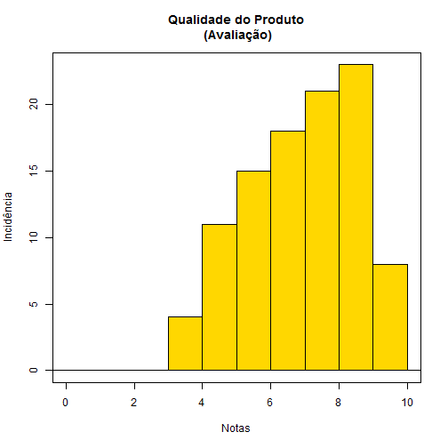

```r
with(cel, Hist(X7QualidadedoProduto, scale="frequency", breaks="Sturges",
  col="#FFD700", xlab="Notas", ylab="Incidência", xlim=c(0,10),
  main="Qualidade do Produto\n (Avaliação)"))
```

```r
x11()
```

#### Experiência “Acesso à Internet por Localidade”

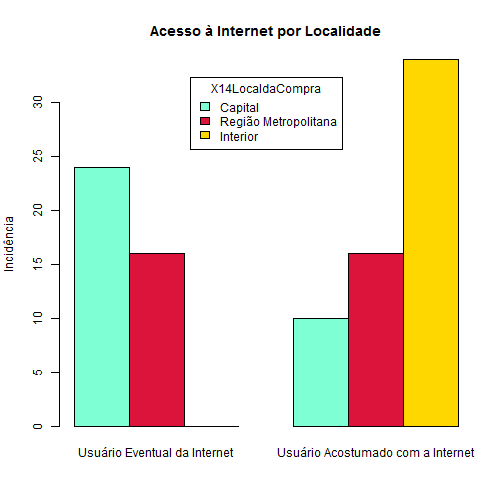

```r
with(cel, Barplot(X11Internet, by=X14LocaldaCompra, style="parallel",
  legend.pos="top", xlab="", ylab="Incidência",
  main="Acesso à Internet por Localidade",col=c("#7FFFD4","#DC143C",
  "#FFD700")))
```

```r
x11()
```

#### Experiência “Relação Idade e Sexo”

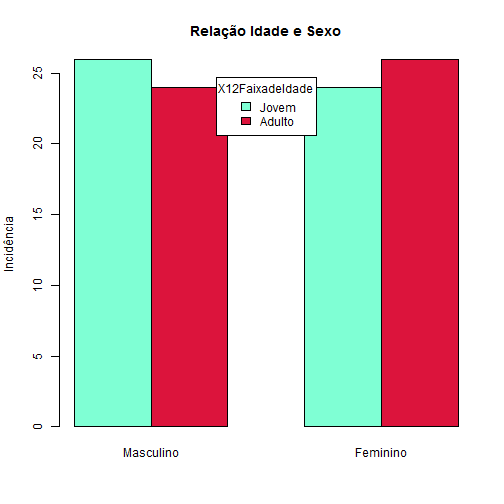

```r
with(cel, Barplot(X13Sexo, by=X12FaixadeIdade, style="parallel",
  legend.pos="top", xlab="", ylab="Incidência", main="Relação Idade e Sexo",
  col=c("#7FFFD4","#DC143C")))
```